# Box Office Performance

#### 3.2.1 **Content rating** overview

The descriptions for content rating we are dealing with are as follows: *format :* **Content rating** - *description*

1. **G** - For all audience. *(source: IMDB)*
2. **PG** - Parental guidance suggested (mainly for under 10’s). *(source: IMDB)*
3. **PG-13** - Parental guidance suggested for children under 13. *(source: IMDB)*
4. **R** - Under 17 not admitted without parent or guardian. *(source: IMDB)*
5. **NC17** - Under 17 not admitted. *(source: IMDB)*
6. **NR** - Not been submitted for a rating or an uncut version of movie. *(source: ATLAS CINEMAS)*

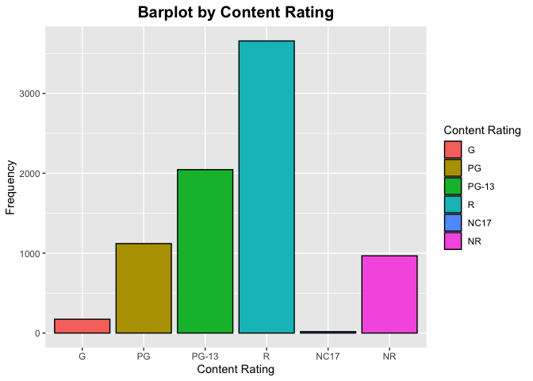

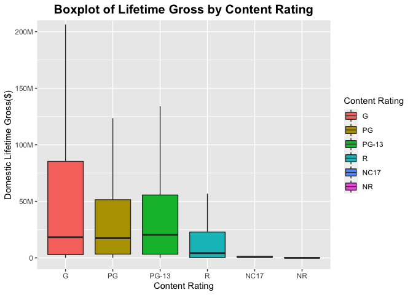

#### 3.2.2 **Year** overview

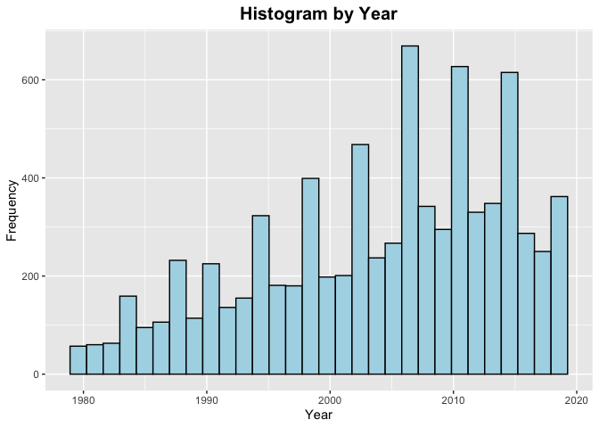

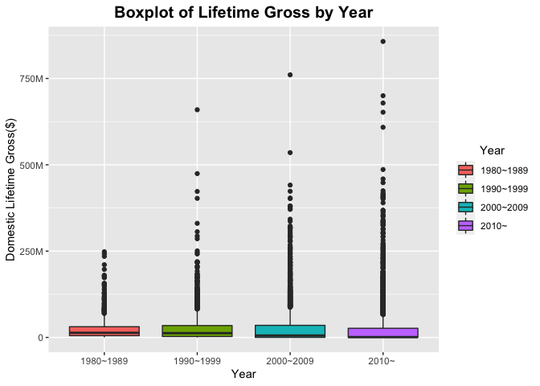

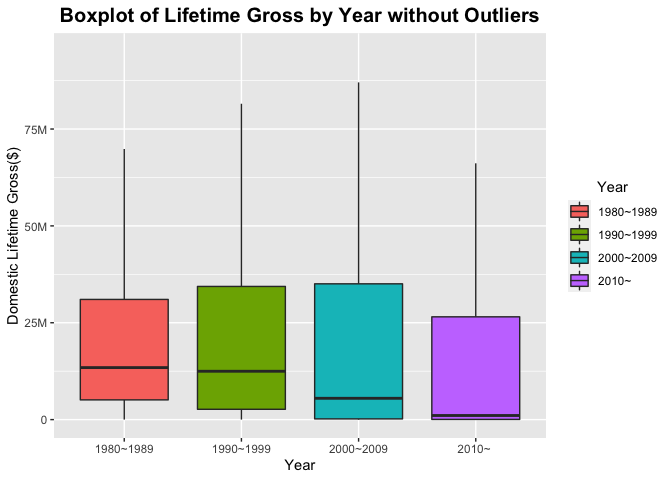

#### 3.2.3 **IMDB rating** overview

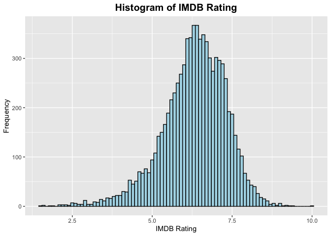

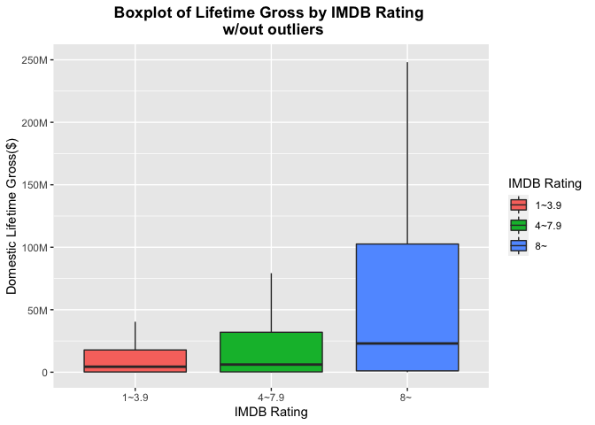

#### 3.2.4 **Rotten Tomatoes rating** overview

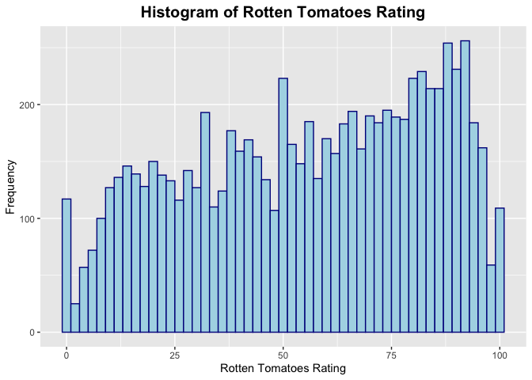

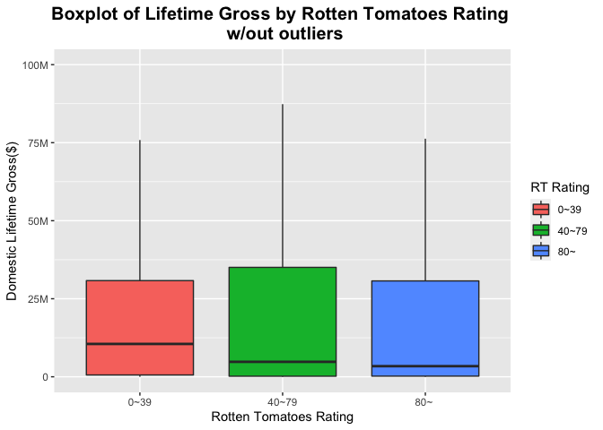

#### 3.2.5 **IMDB count** overview

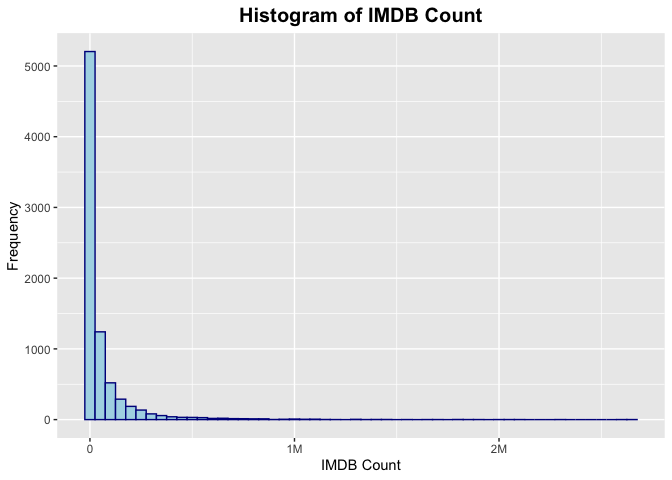

#### 3.2.6 **Rotten Tomatoes count** overview

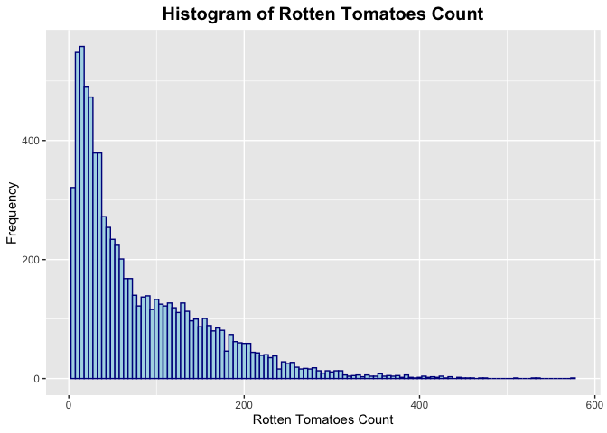

# 4. Variables EDA: Finding out Correlation

### 4.1 SMART Question: Does **rating** affect box office performance?

#### 4.1.1 **IMDB Rating**

##### 4.1.1.1 Scatterplot and Correlation Test

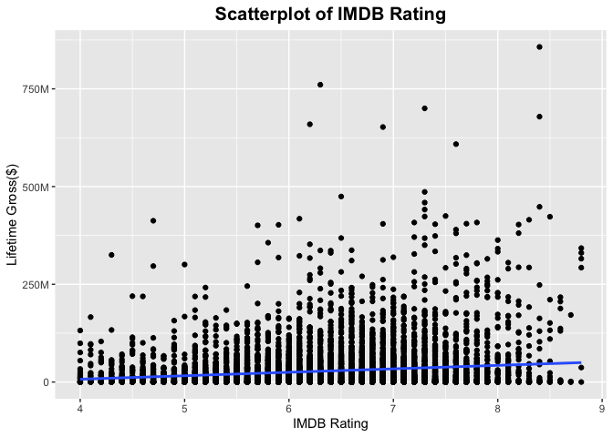

```
##
##  Pearson's product-moment correlation
##
## data:  nooutlierR$imdbR and nooutlierR$LifetimeGross
## t = 12.548, df = 7791, p-value < 0.00000000000000022
## alternative hypothesis: true correlation is not equal to 0
## 95 percent confidence interval:
##  0.1189170 0.1624434
## sample estimates:
##       cor
## 0.1407482
```

##### 4.1.1.2 Hypothesis Test

```
##
##  Welch Two Sample t-test
##
## data:  midimdbR$imdbR and highimdbR$imdbR
## t = -109.65, df = 446.67, p-value < 0.00000000000000022
## alternative hypothesis: true difference in means is not equal to 0
## 95 percent confidence interval:
##  -1.933767 -1.865667
## sample estimates:
## mean of x mean of y
##  6.327135  8.226852
```

#### 4.1.2 **Rotten Tomatoes Rating**

##### 4.1.2.1 Scatterplot and Correlation Test

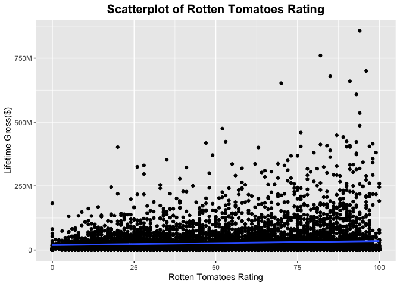

```
##
##  Pearson's product-moment correlation
##
## data:  nooutlierR$rottentmtR and nooutlierR$LifetimeGross
## t = 7.1084, df = 7979, p-value = 0.000000000001276
## alternative hypothesis: true correlation is not equal to 0
## 95 percent confidence interval:
##  0.05748804 0.10109151
## sample estimates:
##        cor
## 0.07932772
```

##### 4.1.2.2 Hypothesis Test

```
##
##  Welch Two Sample t-test
##
## data:  lowrtR$rottentmtR and midrtR$rottentmtR
## t = -157.95, df = 6920.4, p-value < 0.00000000000000022
## alternative hypothesis: true difference in means is not equal to 0
## 95 percent confidence interval:
##  -50.84730 -49.60063
## sample estimates:
## mean of x mean of y
##  21.23045  71.45441
```

```
##
##  Welch Two Sample t-test
##
## data:  midrtR$rottentmtR and highrtR$rottentmtR
## t = -67.547, df = 7468.7, p-value < 0.00000000000000022
## alternative hypothesis: true difference in means is not equal to 0
## 95 percent confidence interval:
##  -18.15166 -17.12781
## sample estimates:
## mean of x mean of y
##  71.45441  89.09415
```

### 4.2 SMART Question: Does **count** affect box office performance?

#### 4.2.1 **IMDB Count**

##### 4.2.1.1 Scatterplot and Correlation Test

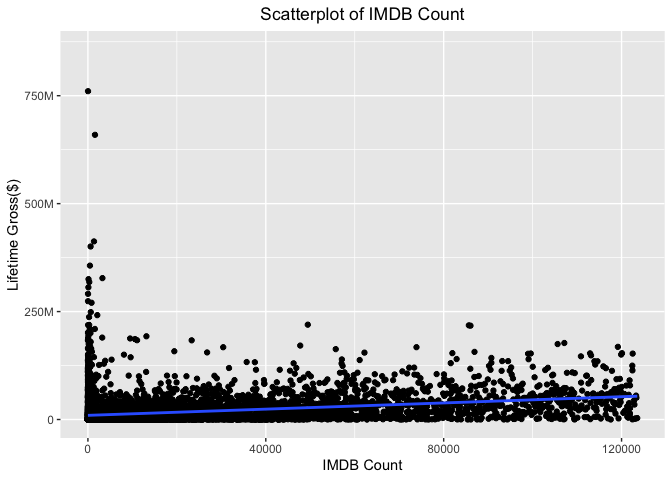

```
##
##  Pearson's product-moment correlation
##
## data:  nooutlierC$imdbC and nooutlierC$LifetimeGross
## t = 27.325, df = 6957, p-value < 0.00000000000000022
## alternative hypothesis: true correlation is not equal to 0
## 95 percent confidence interval:
##  0.2899501 0.3323892
## sample estimates:
##       cor
## 0.3113249
```

#### 4.2.2 **Rotten Tomatoes Count**

##### 4.2.2.1 Scatterplot and Correlation Test

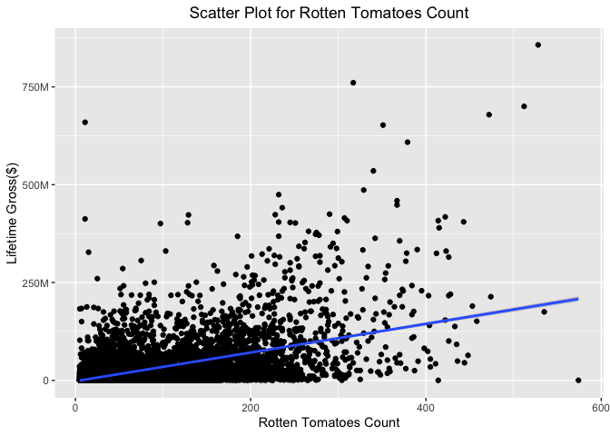

```
##
##  Pearson's product-moment correlation
##
## data:  nooutlierC$rottentmtC and nooutlierC$LifetimeGross
## t = 52.538, df = 7979, p-value < 0.00000000000000022
## alternative hypothesis: true correlation is not equal to 0
## 95 percent confidence interval:
##  0.4904925 0.5230979
## sample estimates:
##       cor
## 0.5069765
```

# 5. Linear Regression Model

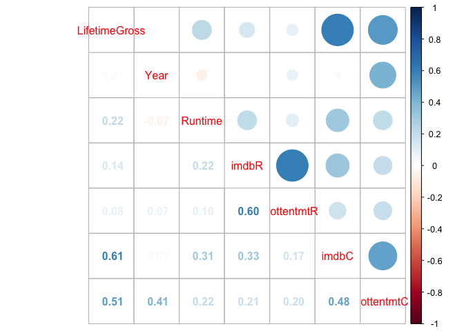

### 5.1 Model Fitting: Goals and Overview

### 5.2 Model Results Summary and Interpretations

```
##
## Call:
## lm(formula = LifetimeGross ~ imdbC, data = movie)
##
## Residuals:
##        Min         1Q     Median         3Q        Max
## -565376675  -15245362  -13575285    3703965  745848912
##
## Coefficients:
##                 Estimate   Std. Error t value            Pr(>|t|)
## (Intercept) 14653679.219   538044.674   27.23 <0.0000000000000002 ***
## imdbC            218.858        3.236   67.63 <0.0000000000000002 ***
## ---
## Signif. codes:  0 '***' 0.001 '**' 0.01 '*' 0.05 '.' 0.1 ' ' 1
##
## Residual standard error: 44310000 on 7855 degrees of freedom
## Multiple R-squared:  0.368,  Adjusted R-squared:  0.3679
## F-statistic:  4574 on 1 and 7855 DF,  p-value: < 0.00000000000000022
```

```
##
## Call:
## lm(formula = LifetimeGross ~ imdbC + rottentmtC, data = movie)
##
## Residuals:
##        Min         1Q     Median         3Q        Max
## -437924546  -15595222   -5009550    5592556  694696473
##
## Coefficients:
##               Estimate Std. Error t value            Pr(>|t|)
## (Intercept) 814755.667 697453.730   1.168               0.243
## imdbC          170.106      3.499  48.610 <0.0000000000000002 ***
## rottentmtC  205023.608   7030.491  29.162 <0.0000000000000002 ***
## ---
## Signif. codes:  0 '***' 0.001 '**' 0.01 '*' 0.05 '.' 0.1 ' ' 1
##
## Residual standard error: 42090000 on 7854 degrees of freedom
## Multiple R-squared:  0.4297, Adjusted R-squared:  0.4296
## F-statistic:  2959 on 2 and 7854 DF,  p-value: < 0.00000000000000022
```

```
##
## Call:
## lm(formula = LifetimeGross ~ imdbC + rottentmtC + Runtime, data = movie)
##
## Residuals:
##        Min         1Q     Median         3Q        Max
## -435621020  -15587477   -4972775    5499731  692415264
##
## Coefficients:
##                 Estimate   Std. Error t value            Pr(>|t|)
## (Intercept) -3663691.882  2539790.943  -1.443              0.1492
## imdbC            168.501        3.607  46.719 <0.0000000000000002 ***
## rottentmtC    203958.914     7053.370  28.917 <0.0000000000000002 ***
## Runtime        45788.395    24969.255   1.834              0.0667 .
## ---
## Signif. codes:  0 '***' 0.001 '**' 0.01 '*' 0.05 '.' 0.1 ' ' 1
##
## Residual standard error: 42090000 on 7853 degrees of freedom
## Multiple R-squared:   0.43,  Adjusted R-squared:  0.4298
## F-statistic:  1975 on 3 and 7853 DF,  p-value: < 0.00000000000000022
```

ANOVA: Models 1, 2, & 3

```
## Analysis of Variance Table
##
## Model 1: LifetimeGross ~ imdbC + rottentmtC + Runtime
## Model 2: LifetimeGross ~ imdbC + rottentmtC
## Model 3: LifetimeGross ~ imdbC
##   Res.Df                  RSS Df            Sum of Sq        F
## 1   7853 13910690839921960960
## 2   7854 13916647636689465344 -1    -5956796767504384   3.3628
## 3   7855 15423533030382118912 -1 -1506885393692653568 850.6818
##                 Pr(>F)
## 1
## 2              0.06672 .
## 3 < 0.0000000000000002 ***
## ---
## Signif. codes:  0 '***' 0.001 '**' 0.01 '*' 0.05 '.' 0.1 ' ' 1
```

```
##
## Call:
## lm(formula = LifetimeGross ~ imdbC + rottentmtC + contentR, data = movie)
##
## Residuals:
##        Min         1Q     Median         3Q        Max
## -420968348  -17548472   -2946511    6895314  687923266
##
## Coefficients:
##                    Estimate    Std. Error t value             Pr(>|t|)
## (Intercept)    30866282.802   3142917.968   9.821 < 0.0000000000000002 ***
## imdbC               167.208         3.379  49.484 < 0.0000000000000002 ***
## rottentmtC       201123.014      7006.464  28.705 < 0.0000000000000002 ***
## contentRPG    -11636242.893   3345078.671  -3.479             0.000507 ***
## contentRPG-13 -22041765.200   3254803.165  -6.772      0.0000000000136 ***
## contentRR     -39047710.938   3189778.307 -12.242 < 0.0000000000000002 ***
## contentRNC17  -45985496.768  10066311.070  -4.568      0.0000049930499 ***
## contentRNR    -35387703.408   3389060.945 -10.442 < 0.0000000000000002 ***
## ---
## Signif. codes:  0 '***' 0.001 '**' 0.01 '*' 0.05 '.' 0.1 ' ' 1
##
## Residual standard error: 40600000 on 7849 degrees of freedom
## Multiple R-squared:  0.4697, Adjusted R-squared:  0.4693
## F-statistic: 993.3 on 7 and 7849 DF,  p-value: < 0.00000000000000022
```

ANOVA: Models 2 & 4

```
## Analysis of Variance Table
##
## Model 1: LifetimeGross ~ imdbC + rottentmtC + contentR
## Model 2: LifetimeGross ~ imdbC + rottentmtC
##   Res.Df                  RSS Df           Sum of Sq      F
## 1   7849 12940522052518782976
## 2   7854 13916647636689465344 -5 -976125584170682368 118.41
##                  Pr(>F)
## 1
## 2 < 0.00000000000000022 ***
## ---
## Signif. codes:  0 '***' 0.001 '**' 0.01 '*' 0.05 '.' 0.1 ' ' 1
```